# Bicep Curl Prediction

Nate Foulkes

10/24/2021

# Assignment description

One thing that people regularly do is quantify how much of a particular activity they do, but they rarely quantify how well they do it. In this project, the goal will be to use data from accelerometers on the belt, forearm, arm, and dumbbell of 6 participants who each performed a bicep curl in 5 different ways. The goal is to find a quality predictive algorithm.  
Using the caret and parsnip packages. The process created two different methods of pre-process (i.e. normalized and PCA). Then created three models: tree, generalized linear, and random forest. Build workflows combing each pre-process and model. Look at the metrics of each model. Eliminate poor performing models. Resample then retrain the better performing models to try and improve the fit. Finally apply the best fitting model to the unseen testing data.

# What to use as predictors:

The original files are read-in using read_csv function. After examining the structure of the data there appeared to be a large proportion of missing values. It was judged that those columns are summary values of other columns, were not necessary, and were immediately cut from the data set.

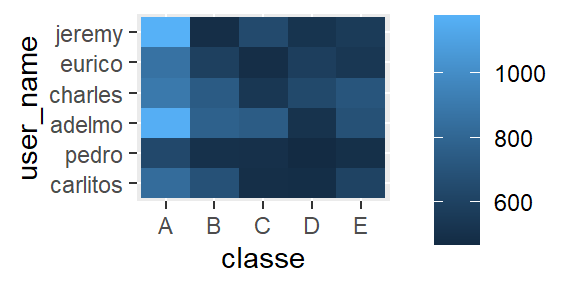

The heat map above doesn’t suggest that there is a significant skew to the data when comparing the category of type of bicep curl to participant.

## Recipes

The norm_center_recipe changed nominal values into dummy variables, looked for “near zero variance” in each of the predictors, and normalized each numeric predictor. The pca_recipe used the the method of Principal Component Analysis (and changed nominal predictors to dummy variables).

# Algorithms

We analyzed the training data using three different methods: multinomial regression, a tree model, and a random forest model. Each model was run twice: once with the normalized and centered recipe, and then again with the PCA recipe. Once the models were fit to the training data we examined the ROC and AUC values. Models with low ROC and AUC were eliminated from the prediction model. Those with high values of ROC and AUC were then resampled to try and improve the fit.  
The receiver operating characteristic curve (ROC) is used for assessing the tradeoff between sensitivity and specificity.

### Resampling methods

Once we found methods that offered decent results those methods were resampled to find a better prediction model. The resampling was done using cross validation for the tree model and repeated cross validation for the random forest.

## Multinomial Regression

The regression used the glmnet engine: a parsnip package that fits a generalized linear model via penalized maximum likelihood. From previous analysis it seemed reasonable to set the penalty to 0.1. So those predictors with penalty coefficients larger than 0.1 were minimized in the final regression.

The multinomial regression was not a great fit for either type of pre-processing. The PCA AUC was only 0.583 and the Normalized AUC was 0.642.

## Tree Model

Decision Tree models are created using 2 steps: Induction and Pruning. Induction is where we actually build the tree i.e set all of the hierarchical decision boundaries based on our data. Because of the nature of training decision trees they can be prone to major overfitting. Pruning is the process of removing the unnecessary structure from a decision tree, effectively reducing the complexity to combat overfitting with the added bonus of making it even easier to interpret.

The tree model gave better estimates of prediction compared to the multinomial regression. The Normalized estimate was 0.855 and the PCA estimate was 0.64.

## Random Forest Model

The random forest is an extension upon the tree model. However, the difference is that a forest makes a large number of relatively uncorrelated trees to operate like a committee to create the models.

The random forest models gave the best estimates. The PCA estimate was 0.993 and the Normalized estimate was 1. At this point I would of chosen to use the PCA model - or at least change the pre-processing and resampling functions to try get a better fit using the PCA. Getting an estimate of 1 in the random forest normalized model should raise alarm bells.

# Resample the better models

Since the tree and random forest models seemed to give the better predictive models those models were resampled using cross-validation and the repeated cross-validation methods. Below you can visualize the predictive capabilities of each model. The graph shows that the random forest model is a better predictor than the tree model.

### AUC Plots

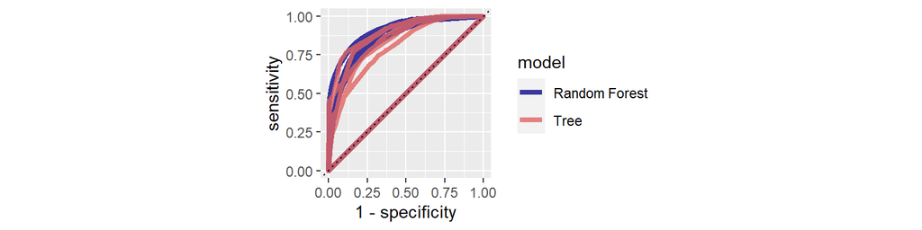

# Test the predictors:

Using the random forest normalized model on the test data gives:

```r
knitr::kable(randf_nc_test_table$.pred_class, caption = 'Test Data Prediction')
```

Test Data Prediction

| x |
| --- |
| B |
| A |
| B |
| A |
| A |
| E |
| D |
| B |
| A |
| A |
| B |
| C |
| B |
| A |
| E |
| E |
| A |
| B |
| B |
| B |

# Appendix: r code

```r
if(!file.exists("./data")){dir.create("./data")}
url1 <- "https://d396qusza40orc.cloudfront.net/predmachlearn/pml-training.csv"
#download.file(url1, destfile = "./data/pml-training.csv")
url2 <- "https://d396qusza40orc.cloudfront.net/predmachlearn/pml-testing.csv"
#download.file(url2, destfile = "./data/pml-testing.csv")
## Data Source
website <- "http://web.archive.org/web/20161224072740/http:/groupware.les.inf.puc-rio.br/har. "
# libraries used
library(tidyverse) #*
library(caret)#*
library(tidymodels) #* for the dials fuction
library(parsnip)#*
library(recipes)#*
library(workflows)#*
library(yardstick)#* for the roc_auc
# read in the data files
pml_test <- read_csv("./data/pml-testing.csv")
pml_train <- read_csv("./data/pml-training.csv")
# making NA explicit
pml_test <- pml_test %>% complete(.)
pml_train <- pml_train %>% complete(.)
# Remove the columns with more than 90% NA values
pml_test <-
        pml_test[,!sapply(pml_test,
                function(x) mean(is.na(x)))>0.9]
pml_train <-
        pml_train[,!sapply(pml_train,
                function(x) mean(is.na(x)))>0.9]
# convert classe and user_name into factors
pml_train$classe <-
        parse_factor(pml_train$classe,
                     levels = c("A","B","C","D","E"),
                     ordered = FALSE)
pml_train$user_name <-
        parse_factor(pml_train$user_name,
                     levels = c("carlitos", "pedro","adelmo",
                                "charles","eurico","jeremy"),
                     ordered = FALSE)
pml_test$user_name <-
        parse_factor(pml_test$user_name,
                     levels = c("carlitos", "pedro","adelmo",
                                "charles","eurico","jeremy"),
                     ordered = FALSE)
# get rid of the index, time, and window cols
pml_test <-
        pml_test %>%
        select(-(...1 | raw_timestamp_part_1:num_window))
pml_train <-
        pml_train %>%
        select(-(...1 | raw_timestamp_part_1:num_window))
# image of user versus classe
pml_train %>% count(classe, user_name) %>%
        ggplot(mapping = aes(x=classe,y=user_name)) +
        geom_tile(mapping = aes(fill=n))
# Normalized Recipe
norm_center_recipe <-
        recipe(classe ~ ., data = pml_train) %>%
        step_dummy(all_nominal_predictors()) %>%
        step_nzv(all_predictors()) %>%
        step_normalize(all_numeric_predictors())
# Principal Component Analysis Recipe
pca_recipe <-
        recipe(classe ~., data = pml_train) %>%
        step_dummy(all_nominal_predictors()) %>%
        step_pca(all_numeric_predictors(), num_comp = 4)
# used to create the AUC plots
keep_pred <- control_resamples(save_pred = TRUE, save_workflow = FALSE)
## Cross-Validation
set.seed(42)
pml_folds <- vfold_cv(pml_train, v=5) # used in tree resample
## Repeated Cross-Validation
r_cv <- vfold_cv(pml_train, v = 5, repeats = 5) # used in randf resample
# multinomial model
mr_model <-
        multinom_reg(penalty = 0.1) %>%
        set_engine("glmnet") %>%
        set_mode("classification")
# Normalized and Centered
mr_workflow_nc <-
        workflow() %>%
        add_model(mr_model) %>%
        add_recipe(norm_center_recipe)
# Fit the mr nc model
set.seed(234)
mr_fit_nc <-
        mr_workflow_nc %>%
        fit(data = pml_train)
# Predict using the norm center model
mr_training_pred_nc <-
        predict(mr_fit_nc, pml_train) %>%
        bind_cols(predict(mr_fit_nc, pml_train, type = "prob")) %>%
        bind_cols(pml_train %>% select(classe))
## Check the quality of fit
mr_nc_roc_auc <-
        mr_training_pred_nc %>%
        roc_auc(truth = pml_train$classe,
                .pred_A, .pred_B, .pred_C, .pred_D, .pred_E)
mr_nc_accuracy <-
        mr_training_pred_nc %>%
        accuracy(truth = pml_train$classe, .pred_class)
mr_nc_est <-
        round(mr_nc_roc_auc$.estimate,3)
# multinomial PCA
mr_workflow_pca <-
        workflow() %>%
        add_model(mr_model) %>%
        add_recipe(pca_recipe)
## fit the pca model
set.seed(234)
mr_fit_pca <-
        mr_workflow_pca %>%
        fit(data = pml_train)
## predict with the pca model
mr_training_pred_pca <-
        predict(mr_fit_pca, pml_train) %>%
        bind_cols(predict(mr_fit_pca, pml_train, type = "prob")) %>%
        bind_cols(pml_train %>% select(classe))
## Check the quality of fit
mr_pca_roc_auc <-
        mr_training_pred_pca %>%
        roc_auc(truth = pml_train$classe,
                .pred_A, .pred_B,
                .pred_C, .pred_D, .pred_E)
mr_pca_accuracy <-
        mr_training_pred_pca %>%
        accuracy(truth = pml_train$classe, .pred_class)
mr_pca_estimate <-
        round(mr_pca_roc_auc$.estimate,3)
# Tree model
tune_spec <-
        decision_tree(cost_complexity = 0.02,
                      tree_depth = 10,
                      min_n = 1000) %>%
        set_engine("rpart") %>%
        set_mode("classification")
# Normalized and Centered
tree_wf_nc <-
        workflow() %>%
        add_model(tune_spec) %>%
        add_recipe(norm_center_recipe)
# fit the tree norm center recipe
set.seed(234)
tree_fit_nc <-
        tree_wf_nc %>%
        fit(data=pml_train)
# Predict tree using the norm center model
tree_pred_nc <-
        predict(tree_fit_nc, pml_train) %>%
        bind_cols(predict(tree_fit_nc, pml_train, type = "prob")) %>%
        bind_cols(pml_train %>% select(classe))
## Check quality of fit
tree_nc_roc_auc <-
        tree_pred_nc %>%
        roc_auc(truth = pml_train$classe,
                .pred_A, .pred_B, .pred_C, .pred_D, .pred_E)
tree_nc_accuracy <-
        tree_pred_nc %>%
        accuracy(truth = pml_train$classe, .pred_class)
tree_nc_est <-
        round(tree_nc_roc_auc$.estimate,3)
# PCA
tree_wf_pca <-
        workflow() %>%
        add_model(tune_spec) %>%
        add_recipe(pca_recipe)
# Fit tree using the pca recipe
set.seed(567)
tree_fit_pca <-
        tree_wf_pca %>%
        fit(data=pml_train)
# Predict tree using the pca recipe
tree_pred_pca <-
        predict(tree_fit_pca, pml_train) %>%
        bind_cols(predict(tree_fit_pca, pml_train, type = "prob")) %>%
        bind_cols(pml_train %>% select(classe))
tree_pca_roc_auc <-
        tree_pred_pca %>%
        roc_auc(truth = pml_train$classe,
                .pred_A, .pred_B, .pred_C, .pred_D, .pred_E)
tree_pca_accuracy <-
        tree_pred_pca %>%
        accuracy(truth = pml_train$classe, .pred_class)
tree_pca_est <-
        round(tree_pca_roc_auc$.estimate, 3)
# Random Forest model
randf_model <-
        rand_forest(mtry = 5, trees = 10) %>%
        set_engine("ranger", importance = "impurity") %>%
        set_mode("classification")
# Train PCA
randf_wf_pca <-
        workflow() %>%
        add_model(randf_model) %>%
        add_recipe(pca_recipe)
## Fit the PCA
set.seed(567)
randf_fit_pca <-
        randf_wf_pca %>%
        fit(data=pml_train)
# Predict randf using the pca recipe
randf_pred_pca <-
        predict(randf_fit_pca, pml_train) %>%
        bind_cols(predict(randf_fit_pca, pml_train, type = "prob")) %>%
        bind_cols(pml_train %>% select(classe))
## Check quality of fit
randf_pca_roc_auc <-
        randf_pred_pca %>%
        roc_auc(truth = pml_train$classe,
                .pred_A, .pred_B, .pred_C, .pred_D, .pred_E)
randf_pca_accuracy <-
        randf_pred_pca %>%
        accuracy(truth = pml_train$classe, .pred_class)
randf_pca_est <-
        round(randf_pca_roc_auc$.estimate, 3)
# Normalized and Centered
randf_wf_nc <-
        workflow() %>%
        add_model(randf_model) %>%
        add_recipe(norm_center_recipe)
## Fit Random Forest Normalized and Centered
set.seed(234)
randf_fit_nc <-
        randf_wf_nc %>%
        fit(data=pml_train)
## Predict using the randf norm center model
randf_pred_nc <-
        predict(randf_fit_nc, pml_train) %>%
        bind_cols(predict(randf_fit_nc, pml_train, type = "prob")) %>%
        bind_cols(pml_train %>% select(classe))
## Check quality of fit
randf_nc_roc_auc <-
        randf_pred_nc %>%
        roc_auc(truth = pml_train$classe,
                .pred_A, .pred_B, .pred_C, .pred_D, .pred_E)
randf_nc_accuracy <-
        randf_pred_nc %>%
        accuracy(truth = pml_train$classe, .pred_class)
randf_nc_est <-
        round(randf_nc_roc_auc$.estimate, 3)
## Resampled Tree
tree_grid <-
        grid_regular(cost_complexity(),
                     tree_depth(),
                     levels = 5)
tree_res_cv <-
        tree_wf_nc %>%
        fit_resamples(pml_folds, control = keep_pred)
which_best <-
        tree_res_cv %>%
        show_best("accuracy")
best_tree <-
        tree_res_cv %>%
        select_best("accuracy")
tree_nc_auc <-
        tree_res_cv %>%
        collect_predictions(parameters = best_tree) %>%
        roc_curve(classe,
                  .pred_A, .pred_B, .pred_C,
                  .pred_D, .pred_E) %>%
        mutate(model = "Tree")
## Resampled  random forest
set.seed(345)
randf_pca_res <-
        randf_wf_pca %>%
        tune_grid(r_cv,
                  grid = 25,
                  control = control_grid(save_pred = TRUE),
                  metrics = metric_set(roc_auc))
randf_pca_res %>% show_best(metric = "roc_auc")
randf_pca_best <-
        randf_pca_res %>%
        select_best(metric = "roc_auc")
randf_pca_auc <-
        randf_pca_res %>%
        collect_predictions(parameters = randf_pca_best) %>%
        roc_curve(classe, .pred_A, .pred_B, .pred_C, .pred_D, .pred_E) %>%
        mutate(model = "Random Forest")
# AUC plot
bind_rows(randf_pca_auc, tree_nc_auc) %>%
        ggplot(aes(x = 1 - specificity,
                   y = sensitivity, col = model)) +
        geom_path(lwd = 1.5, alpha = 0.8) +
        geom_abline(lty = 3) +
        coord_equal() +
        scale_color_viridis_d(option = "plasma", end = .6)
## Test PCA Random Forest model
randf_pca_fit <- fit(randf_wf_pca, data = pml_train)
final_randf_pca_predict <-
        bind_cols(
        predict(randf_pca_fit, pml_test),
        predict(randf_pca_fit, pml_test, type = "prob"))
randf_pca_test_table <-
        final_randf_pca_predict
## Test the randf norm center model
randf_nc_fit <- fit(randf_wf_nc, data = pml_train)
final_randf_nc_predict <-
        bind_cols(
        predict(randf_nc_fit, pml_test),
        predict(randf_nc_fit, pml_test, type = "prob"))
randf_nc_test_table <-
        final_randf_nc_predict
knitr::kable(randf_nc_test_table$.pred_class, caption = 'Test Data Prediction')
```